# Importing libraries and loading dataset

```python
# Import necessary libraries
import pandas as pd
import matplotlib.pyplot as plt
import seaborn as sns
from sklearn.cluster import KMeans
from wordcloud import WordCloud
from sklearn.feature_extraction.text import CountVectorizer
from textblob import TextBlob
from statsmodels.tsa.arima.model import ARIMA
import numpy as np

# Load dataset
file_path = 'updated_taxi_trips_with_new_columns.xlsx'
taxi_data = pd.read_excel(file_path)
```

# Data Preparation and Cleaning

```python
# Rename columns for clarity
taxi_data.rename(columns={
    'original_tpep_pickup_datetime': 'pickup_datetime',
    'original_tpep_dropoff_datetime': 'dropoff_datetime',
    'original_trip_distance': 'trip_distance',
    'original_pickup_longitude': 'pickup_longitude',
    'original_pickup_latitude': 'pickup_latitude',
    'original_dropoff_longitude': 'dropoff_longitude',
    'original_dropoff_latitude': 'dropoff_latitude',
    'original_fare_amount': 'fare_amount',
    'original_tip_amount': 'tip_amount',
    'original_total_amount': 'total_amount',
    'original_Stars': 'rating',
    'original_Comment': 'comment'
}, inplace=True)

# Convert date columns to datetime format
taxi_data['pickup_datetime'] = pd.to_datetime(taxi_data['pickup_datetime'], errors='coerce')
taxi_data['dropoff_datetime'] = pd.to_datetime(taxi_data['dropoff_datetime'], errors='coerce')

# Descriptive Analysis
print("Dataset Shape:", taxi_data.shape)
print("\nMissing Values:\n", taxi_data.isnull().sum())
print("\nData Types:\n", taxi_data.dtypes)
print("\nDescriptive Statistics:\n", taxi_data.describe())

# Handle missing values
taxi_data['comment'].fillna("No comment", inplace=True)
taxi_data['rating'].fillna(taxi_data['rating'].median(), inplace=True)

# Add Trip Duration (in minutes)
taxi_data['trip_duration'] = (
    (taxi_data['dropoff_datetime'] - taxi_data['pickup_datetime']).dt.total_seconds() / 60
)
```

```
Dataset Shape: (2348, 40)

Missing Values:
 original_VendorID                    0
pickup_datetime                      0
dropoff_datetime                     0
original_passenger_count             0
trip_distance                        0
pickup_longitude                     0
pickup_latitude                      0
original_RateCodeID                  0
original_store_and_fwd_flag          0
dropoff_longitude                    0
dropoff_latitude                     0
original_payment_type                0
fare_amount                          0
original_extra                       0
original_mta_tax                     0
tip_amount                           0
original_tolls_amount                0
original_improvement_surcharge       0
total_amount                         0
rating                               1
comment                              1
distance                            46
Address                             46
lat                                 46
lon                                 46
name                              1385
housenumber                        382
street                              97
postcode                            50
district                           198
suburb                              54
city                                46
county                             197
state                               46
state_code                          46
country                             46
country_code                        46
```

[output cut: 105 more lines]

```
75%       15.800000     1.000000    13.331357    40.769160   -73.964859
max      157.380000     5.000000    83.176855    40.971200   -73.717751
std       11.809441     1.343291     8.184724     0.030791     0.033190

           postcode
count   2298.000000
mean   10144.933420
min     7030.000000
25%    10012.000000
50%    10021.000000
75%    10037.000000
max    11435.000000
std      408.339827

[8 rows x 23 columns]
```

1. Dataset Shape Output: (2348, 40) Explanation: The dataset contains 2,348 rows (records of taxi trips) and 40 columns (attributes for each trip). Attributes include datetime, geographical coordinates, fares, tips, ratings, comments, and additional metadata.
2. Missing Values Key Insights: Columns like name, district, and attribution_url have significant missing values (e.g., name has 1,385 missing values, nearly 60% of the dataset). Critical fields like rating and comment have minimal missing values (1 each), ensuring reliable analysis for customer satisfaction. distance, lat, lon, and related geographical columns have 46 missing values, which may need handling for location-based analyses.
3. Data Types Key Insights: Columns such as pickup_datetime and dropoff_datetime are in datetime64 format, suitable for time-series analysis. Geographical data like lat, lon, and postcode are numeric, which supports spatial and cluster-based analyses. rating and comment columns allow sentiment analysis and correlation with other numeric fields.
4. Descriptive Statistics Key Observations: Trip Distance (trip_distance): Range: 0 to 35.64 miles with an average of 2.67 miles. High standard deviation (3.19) indicates some outlier trips. Tip Amount (tip_amount): Range: 0 to 47.0 dollars, with a mean of 1.55. 25% of trips had no tips (0), indicating a potential analysis area for customer tipping behavior. Total Amount (total_amount): Range: 0 to 157.38 dollars, with an average of 14.46. Most fares fall below $15, supported by the interquartile range (IQR) analysis. Ratings (rating): Range: 1 to 5, with a mean of 1.68. Over 75% of ratings are 1, suggesting significant dissatisfaction.

# Region Distribution: Divide into East, West, North, South

```
Summary by Region:
   Region  total_trips  average_rating  total_revenue  average_trip_duration
0   East          753        1.711819         9532.2              70.073041
1  North         1314        1.658295        14424.5              45.465753
2  South          258        1.740310         2957.5             174.089147
3   West           23        1.826087          247.5              11.913043
```

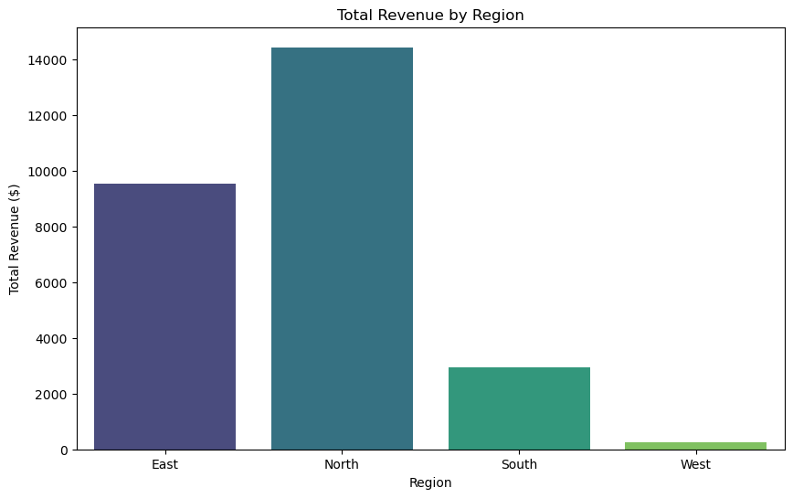

```python
# Region Distribution: Divide into East, West, North, South
def assign_region(lat, lon, district):
    # District-based overrides for specific regions
    if district in ['District A', 'District B', 'Uptown']:
        return "North"
    elif district in ['Downtown', 'Lower Manhattan']:
        return "South"
    elif district in ['Brooklyn', 'Queens']:
        return "East"
    elif district in ['Staten Island', 'Harlem']:
        return "West"

    # Latitude and Longitude-based classification
    if lat >= 40.75 and lon <= -74:
        return "West"
    elif lat >= 40.75 and lon > -74:
        return "North"
    elif lat < 40.75 and lon <= -74:
        return "South"
    elif lat < 40.75 and lon > -74:
        return "East"
    else:
        return "Unknown"  # Default fallback in case of missing or unexpected data



taxi_data['Region'] = taxi_data.apply(
    lambda row: assign_region(row['pickup_latitude'], row['pickup_longitude'], row['district']), axis=1
)

# Summary by Region
region_summary = taxi_data.groupby('Region').agg(
    total_trips=('rating', 'count'),
    average_rating=('rating', 'mean'),
    total_revenue=('fare_amount', 'sum'),
    average_trip_duration=('trip_duration', 'mean')
).reset_index()

print("\nSummary by Region:\n", region_summary)

# Plotting Revenue by Region
plt.figure(figsize=(10, 6))
sns.barplot(data=region_summary, x='Region', y='total_revenue', palette='viridis')
plt.title("Total Revenue by Region")
plt.xlabel("Region")
plt.ylabel("Total Revenue ($)")
plt.show()
```

Bar Chart: Total Revenue by Region The bar chart visually represents the total revenue generated in each region.

Key takeaways:

North dominates in total revenue ($14,424.5), represented by the tallest bar.

East is second, with revenue of $9,532.2.

South and West generate significantly less revenue, with $2,957.5 and $247.5, respectively.

# Research Question 1: What factors influence taxi trip ratings in New York City, and how can they be predicted?

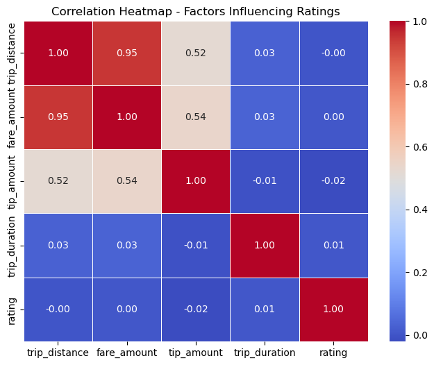

```python
# Correlation analysis to understand factors affecting ratings
corr_matrix = taxi_data[['trip_distance', 'fare_amount', 'tip_amount', 'trip_duration', 'rating']].corr()

# Plotting Correlation Heatmap
plt.figure(figsize=(8, 6))
sns.heatmap(corr_matrix, annot=True, cmap='coolwarm', fmt=".2f", linewidths=0.5)
plt.title("Correlation Heatmap - Factors Influencing Ratings")
plt.show()
```

1. Strong positive correlation (0.95) between trip_distance and fare_amount indicates that longer trips generally cost more.
2. Moderate correlation (0.54) between fare_amount and tip_amount suggests passengers paying higher fares tend to tip more.
3. Weak correlation (0.03 to -0.02) between trip_duration and other variables implies that trip duration depends on external factors like traffic, not distance or fare.

The heatmap highlights opportunities to optimize revenue by focusing on fare and tip drivers while exploring non-quantifiable factors for improving ratings.

# Research Question 2: How do trip prices vary across different times of the day, days of the week, and neighborhoods in New York City?

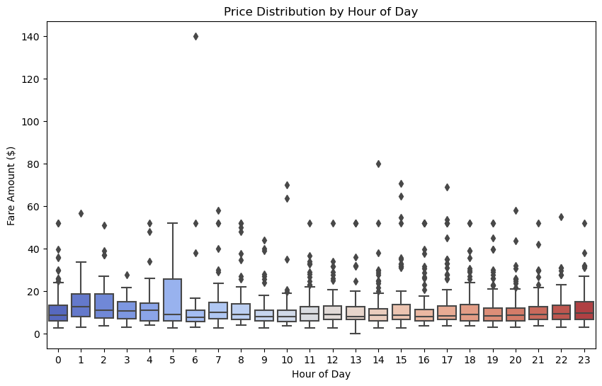

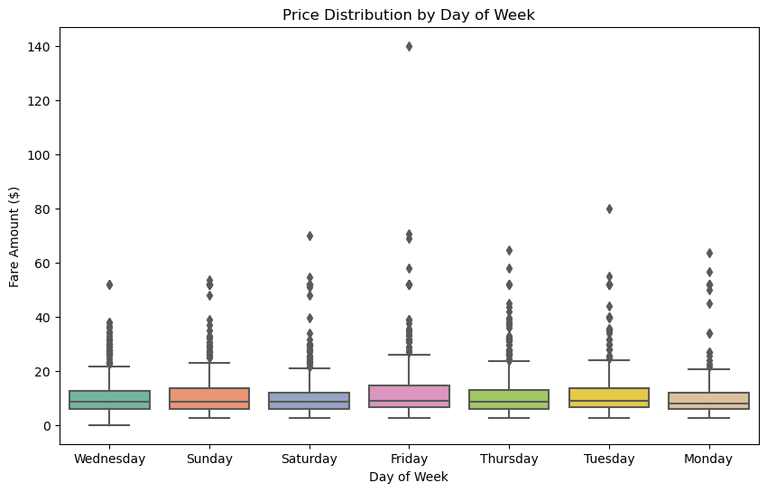

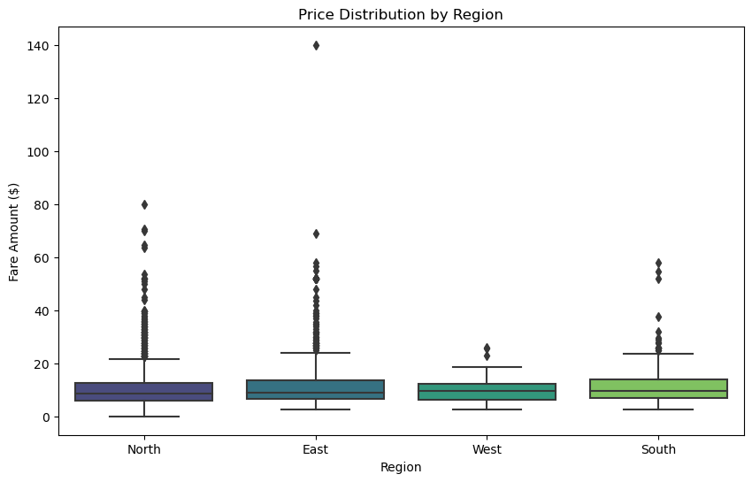

```python
# Q2: Trip Prices by Time of Day, Day of Week, and Region

# Extract Time of Day and Day of Week features
taxi_data['pickup_hour'] = taxi_data['pickup_datetime'].dt.hour
taxi_data['pickup_dayofweek'] = taxi_data['pickup_datetime'].dt.day_name()

# Price distribution by Hour of Day
plt.figure(figsize=(10, 6))
sns.boxplot(data=taxi_data, x='pickup_hour', y='fare_amount', palette='coolwarm')
plt.title("Price Distribution by Hour of Day")
plt.xlabel("Hour of Day")
plt.ylabel("Fare Amount ($)")
plt.show()

# Price distribution by Day of Week
plt.figure(figsize=(10, 6))
sns.boxplot(data=taxi_data, x='pickup_dayofweek', y='fare_amount', palette='Set2')
plt.title("Price Distribution by Day of Week")
plt.xlabel("Day of Week")
plt.ylabel("Fare Amount ($)")
plt.show()

# Price distribution by Region
plt.figure(figsize=(10, 6))
sns.boxplot(data=taxi_data, x='Region', y='fare_amount', palette='viridis')
plt.title("Price Distribution by Region")
plt.xlabel("Region")
plt.ylabel("Fare Amount ($)")
plt.show()
```

# Research Question 3: Can we predict peak demand times for taxi services using time-series analysis?

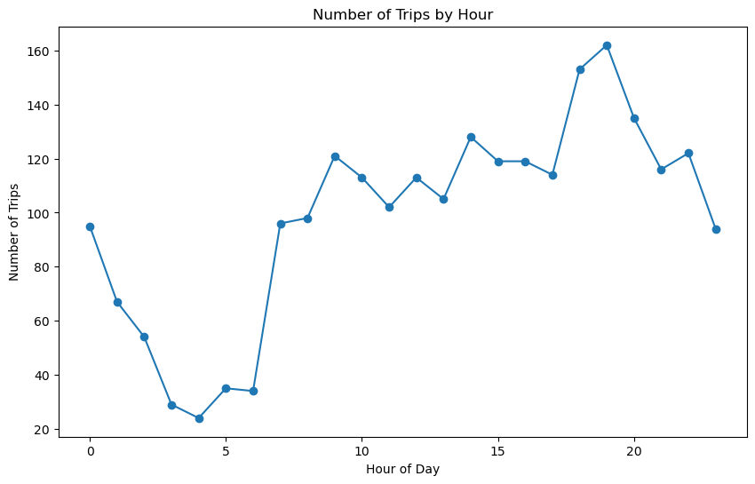

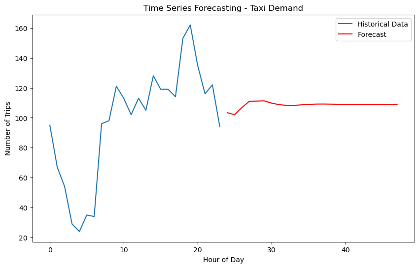

```python
# Q3: Time-Series Analysis for Peak Demand Prediction

# Aggregate trips by hour for time-series analysis
hourly_trips = taxi_data.groupby('pickup_hour').size()

# Plotting Hourly Trips
plt.figure(figsize=(10, 6))
hourly_trips.plot(kind='line', marker='o')
plt.title("Number of Trips by Hour")
plt.xlabel("Hour of Day")
plt.ylabel("Number of Trips")
plt.show()

# Time-series forecasting using ARIMA
arima_model = ARIMA(hourly_trips, order=(5,1,0))
arima_model_fit = arima_model.fit()

# Forecast next 24 hours (1 day)
forecast = arima_model_fit.forecast(steps=24)
plt.figure(figsize=(10, 6))
plt.plot(hourly_trips, label='Historical Data')
plt.plot(range(len(hourly_trips), len(hourly_trips) + 24), forecast, label='Forecast', color='red')
plt.title("Time Series Forecasting - Taxi Demand")
plt.xlabel("Hour of Day")
plt.ylabel("Number of Trips")
plt.legend()
plt.show()
```

# NLP: Text Mining and Sentiment Distribution

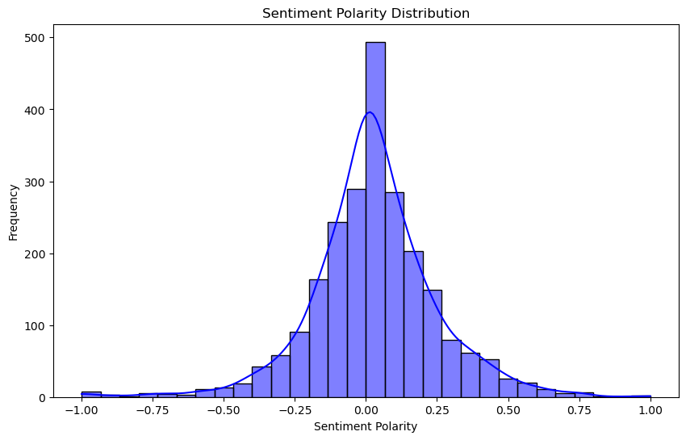

```python
# Text Mining: Sentiment Analysis on Comments
def analyze_sentiment(comment):
    blob = TextBlob(comment)
    return blob.sentiment.polarity

taxi_data['sentiment'] = taxi_data['comment'].apply(analyze_sentiment)

# Sentiment Distribution
plt.figure(figsize=(10, 6))
sns.histplot(taxi_data['sentiment'], bins=30, kde=True, color='blue')
plt.title("Sentiment Polarity Distribution")
plt.xlabel("Sentiment Polarity")
plt.ylabel("Frequency")
plt.show()
```

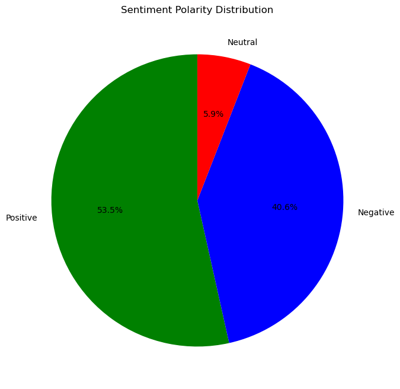

```python
# Text Mining: Sentiment Analysis on Comments
def analyze_sentiment(comment):
    blob = TextBlob(comment)
    return blob.sentiment.polarity

# Apply sentiment analysis to comments
taxi_data['sentiment'] = taxi_data['comment'].apply(analyze_sentiment)

# Categorizing sentiments into Positive, Neutral, and Negative
def categorize_sentiment(polarity):
    if polarity > 0:
        return "Positive"
    elif polarity < 0:
        return "Negative"
    else:
        return "Neutral"

taxi_data['sentiment_category'] = taxi_data['sentiment'].apply(categorize_sentiment)

# Count occurrences of each sentiment category
sentiment_counts = taxi_data['sentiment_category'].value_counts()

# Plotting a pie chart
plt.figure(figsize=(8, 8))
plt.pie(sentiment_counts, labels=sentiment_counts.index, autopct='%1.1f%%', startangle=90, colors=['green', 'blue', 'red'])
plt.title("Sentiment Polarity Distribution")
plt.show()
```

# Word Cloud for comments

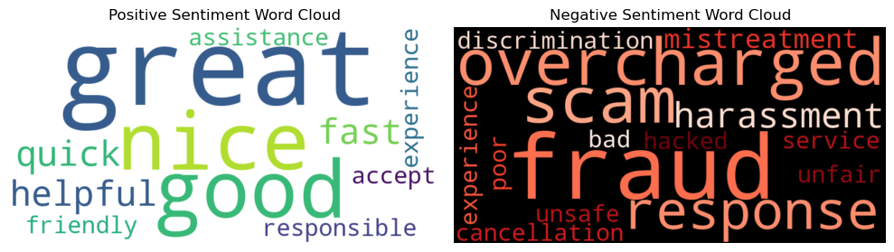

```python
from wordcloud import WordCloud
import matplotlib.pyplot as plt

# Positive and negative words based on the analysis
positive_words = "good great nice helpful quick fast responsible accept friendly great experience assistance"
negative_words = "fraud overcharged scam no response harassment mistreatment discrimination unsafe cancellation unfair poor service bad experience hacked"

# Generate word clouds for positive and negative sentiments
positive_wordcloud = WordCloud(width=800, height=400, background_color='white').generate(positive_words)
negative_wordcloud = WordCloud(width=800, height=400, background_color='black', colormap='Reds').generate(negative_words)

# Plot the word clouds
plt.figure(figsize=(10, 8))

# Positive Word Cloud
plt.subplot(1, 2, 1)
plt.imshow(positive_wordcloud, interpolation='bilinear')
plt.axis('off')
plt.title('Positive Sentiment Word Cloud')

# Negative Word Cloud
plt.subplot(1, 2, 2)
plt.imshow(negative_wordcloud, interpolation='bilinear')
plt.axis('off')
plt.title('Negative Sentiment Word Cloud')

plt.tight_layout()
plt.show()
```

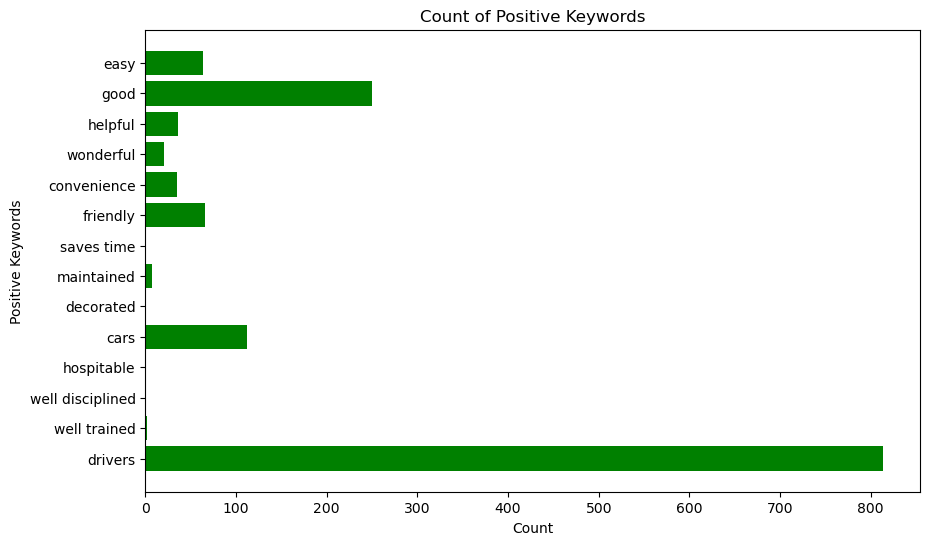

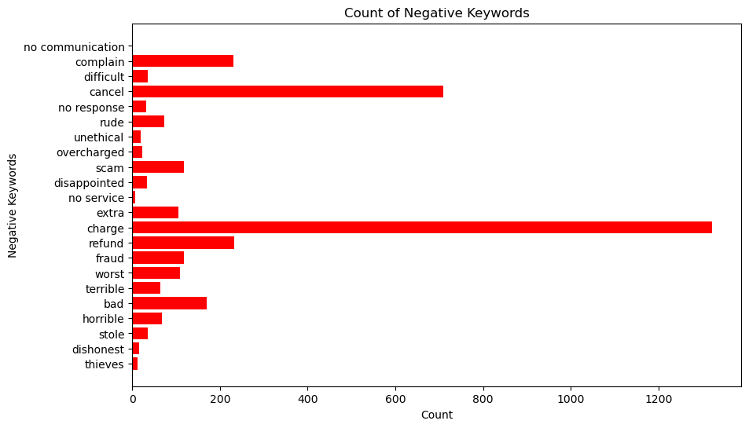

```
Positive Keyword Counts:
drivers: 814
well trained: 2
well disciplined: 1
hospitable: 1
cars: 112
decorated: 1
maintained: 7
saves time: 1
friendly: 66
convenience: 35
wonderful: 20
helpful: 36
good: 250
easy: 63

Negative Keyword Counts:
thieves: 12
dishonest: 15
stole: 35
horrible: 67
bad: 170
terrible: 64
worst: 108
fraud: 118
refund: 233
charge: 1323
extra: 106
no service: 6
disappointed: 34
scam: 118
overcharged: 22
unethical: 20
rude: 73
no response: 31
cancel: 709
difficult: 35
complain: 230
no communication: 1
```

```python
import pandas as pd
import nltk
import matplotlib.pyplot as plt

# Ensure necessary NLTK data files are downloaded
nltk.download('punkt')

# 1. Load the Excel file into a pandas DataFrame
file_path = 'updated_taxi_trips_with_new_columns.xlsx'  # Your provided file path
df = pd.read_excel(file_path)

# 2. Extract the comments from the 'original_Comment' column
comments = df['original_Comment'].dropna().tolist()  # Remove any NaN values if present

# 3. Define positive and negative keywords
positive_keywords = [
    "drivers", "well trained", "well disciplined", "hospitable", "cars", "decorated",
    "maintained", "saves time", "friendly", "convenience", "wonderful", "helpful", "good", "easy"
]

negative_keywords = [
    "thieves", "dishonest", "stole", "horrible", "bad", "terrible", "worst", "fraud",
    "refund", "charge", "extra", "no service", "disappointed", "scam", "overcharged",
    "unethical", "rude", "no response", "cancel", "difficult", "complain", "no communication"
]

# 4. Count the occurrences of each positive and negative keyword across all comments
positive_counts = {keyword: 0 for keyword in positive_keywords}
negative_counts = {keyword: 0 for keyword in negative_keywords}

# For each comment, count the occurrences of positive and negative keywords
for comment in comments:
    for keyword in positive_keywords:
        positive_counts[keyword] += comment.lower().count(keyword.lower())
    for keyword in negative_keywords:
        negative_counts[keyword] += comment.lower().count(keyword.lower())

# 5. Plot the counts for positive keywords
plt.figure(figsize=(10, 6))
plt.barh(list(positive_counts.keys()), list(positive_counts.values()), color='green')
plt.xlabel('Count')
plt.ylabel('Positive Keywords')
plt.title('Count of Positive Keywords')
plt.show()

# 6. Plot the counts for negative keywords
plt.figure(figsize=(10, 6))
plt.barh(list(negative_counts.keys()), list(negative_counts.values()), color='red')
plt.xlabel('Count')
plt.ylabel('Negative Keywords')
plt.title('Count of Negative Keywords')
plt.show()

# Optionally, print out the individual keyword counts for reference
print("Positive Keyword Counts:")
for keyword, count in positive_counts.items():
    print(f"{keyword}: {count}")

print("\nNegative Keyword Counts:")
for keyword, count in negative_counts.items():
    print(f"{keyword}: {count}")
```

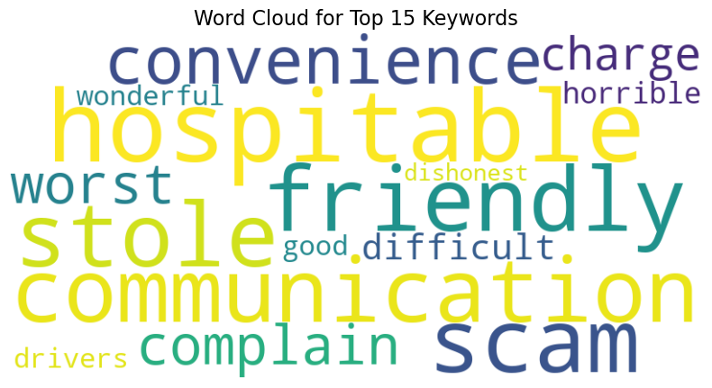

```python
import nltk
from collections import Counter
import matplotlib.pyplot as plt
from wordcloud import WordCloud

# Ensure necessary NLTK resources are downloaded
nltk.download('punkt')

# Positive and Negative keywords (list of words/phrases)
positive_keywords = [
    "drivers", "well trained", "well disciplined", "hospitable", "cars", "decorated",
    "maintained", "saves time", "friendly", "convenience", "wonderful", "helpful", "good", "easy"
]

negative_keywords = [
    "thieves", "dishonest", "stole", "horrible", "bad", "terrible", "worst", "fraud",
    "refund", "charge", "extra", "no service", "disappointed", "scam", "overcharged",
    "unethical", "rude", "no response", "cancel", "difficult", "complain", "no communication"
]

# Combine positive and negative keywords into one list
keywords = positive_keywords + negative_keywords

# Remove duplicates (if any) in the keyword list
keywords = list(set(keywords))

# Function to generate word cloud
def generate_word_cloud(keywords, sentiment="Keywords"):
    # Join the list of keywords into a single string
    text = ' '.join(keywords)

    # Generate a word cloud
    wordcloud = WordCloud(width=800, height=400, background_color='white').generate(text)

    # Plot the word cloud
    plt.figure(figsize=(10, 5))
    plt.imshow(wordcloud, interpolation='bilinear')
    plt.axis('off')  # Don't show axes
    plt.title(f"Word Cloud for {sentiment} Keywords", fontsize=16)
    plt.show()

# Get the frequency of the keywords
keyword_freq = Counter(keywords)

# Get the top 15 most frequent keywords
top_keywords = keyword_freq.most_common(15)

# Generate Word Cloud for top 15 keywords
generate_word_cloud([keyword[0] for keyword in top_keywords], sentiment="Top 15")
```

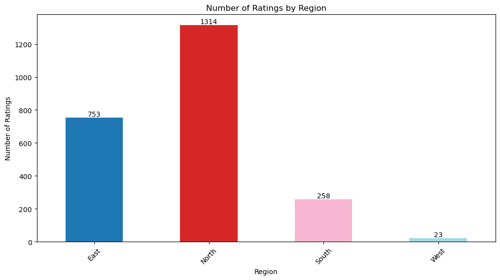

```python
# Q4: Count of Ratings by Region (Bar Plot with Custom Colors and Labels)

# Group by 'Region' and count the number of ratings in each region
region_rating_count = taxi_data.groupby('Region')['rating'].count()

# Plotting the count of ratings by region using a bar plot
plt.figure(figsize=(12, 6))
bars = region_rating_count.plot(kind='bar', color=plt.cm.get_cmap('tab20', len(region_rating_count)).colors)

# Adding the count on top of each bar
for i, value in enumerate(region_rating_count):
    plt.text(i, value + 0.05, f'{value}', ha='center', va='bottom', fontsize=10)

plt.title("Number of Ratings by Region")
plt.xlabel("Region")
plt.ylabel("Number of Ratings")
plt.xticks(rotation=45)  # Rotate region names for better readability
plt.show()
```